# The grammar of ggplot graphics

Alison Link

July 20, 2016

**Related to:** *Data Computing*, “Frames, Glyphs, and other Components of Graphics”, Ch. 6; “Graphics and Their Grammar”, Ch. 8

## ggplot: R’s graphical “sandwich artist”

Have you ever admired the “sandwich artists” who so skillfully put together your sandwich at Subway? Have you ever wanted to learn how to create and serve up graphics that are a feast for the eyes? Well, today’s your lucky day! Pull on your latex gloves and get ready to become a “sandwich”…erm… “graphics” artist!

At this point, you should know how to make a few different basic plots (ex: barplot, histogram, scatterplot). And up until now, you’ve been making these basic plots using built-in “base R” functions and graphics settings. This approach works just fine for exploratory analysis as you’re first getting acquainted with your data. But if you want to make more polished graphics to share as part of a report or publication, you’re going to want up your graphics game a bit. This is where the ggplot library comes in!

Putting together graphics using ggplot is a lot Like making a sub sandwich: you need to decide what kind of “bread” to have on the outside, what kinds of “toppings”" you’re going to have on the inside, and how you’re going to “slice it up” before you serve it. Do you need a graphic that’s as simple and delicious as a single-serving ham and cheese sub? Or do you need a graphic that’s as loaded as a giant party sub, with lots of different topics and slices? Either way, ggplot can help you out.

To get started with ggplot, you’ll need to make sure to install it the first time you use it:

```r
install.packages("ggplot2")
```

After ggplot is successfully installed, every time you want to use it, just make sure to load the library by running the following line of code at the beginning of your project. Generally, you should only need to run this once at the beginning of each R project or session:

```r
library(ggplot2)
```

And before we get started making some graphics, let’s load up the data set on energy and water usage for Minneapolis public buildings. Make sure the .CSV file containing the data is in your R working directory, then load the dataset into your R environment:

```r
data <- read.csv("Benchmarking_Results__CY_2012_Public_Buildings.csv", header=TRUE, na.strings=c("N/A", "Not Available", "#REF!"))
```

#### Pro tip: Why “ggplot2”?

You may be wondering: *Why do I need to load “ggplot2” instead of just simply “ggplot”? What happened to ggplot number 1?* ggplot is a relatively old library, so there *was* an original version called ggplot1. Starting around 2008, however, the library was rewritten as “ggplot2”. The original ggplot is now out of date, and you will need to load ggplot2 to get the most current version. To learn more about ggplot2, check out the [ggplot.org](http://ggplot2.org/) website.

## The Frame: The “bread” for your graphics

Some graphics only need a single “x” value in the aesthetic. For example, here’s the beginning of a plot that looks at the the floor areas of the various buildings in our dataset:

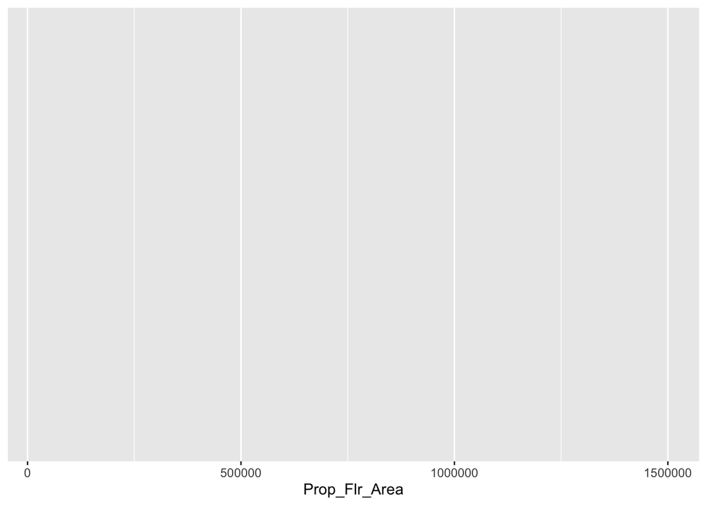

```r
ggplot(data, aes(x=Prop_Flr_Area))
```

Some graphics need both an “x” and a “y” value in the aesthetic. For example, here’s the beginning of a plot comparing the year a building was built (independent variable) to its Energy Star score (dependent variable):

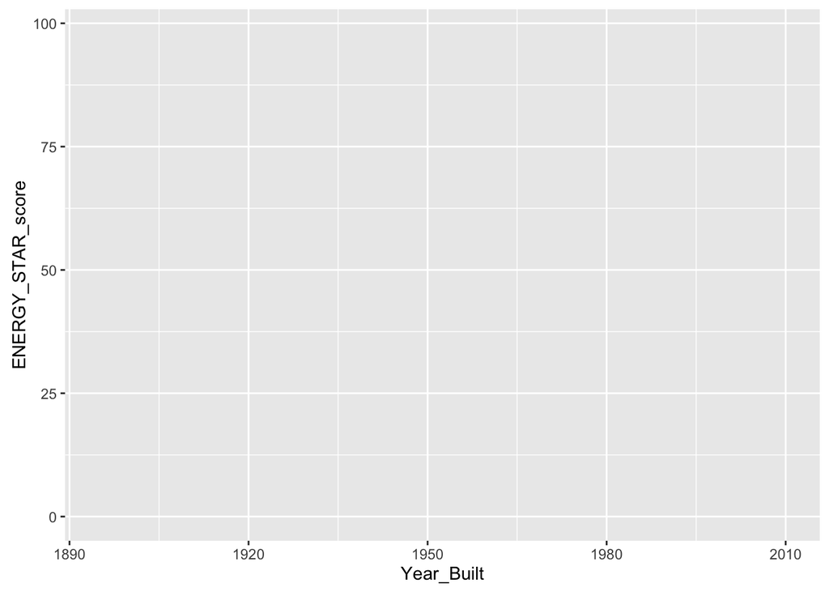

```r
ggplot(data, aes(x=Year_Built, y=ENERGY_STAR_score))
```

#### Pro tip: Adding axis labels and limits

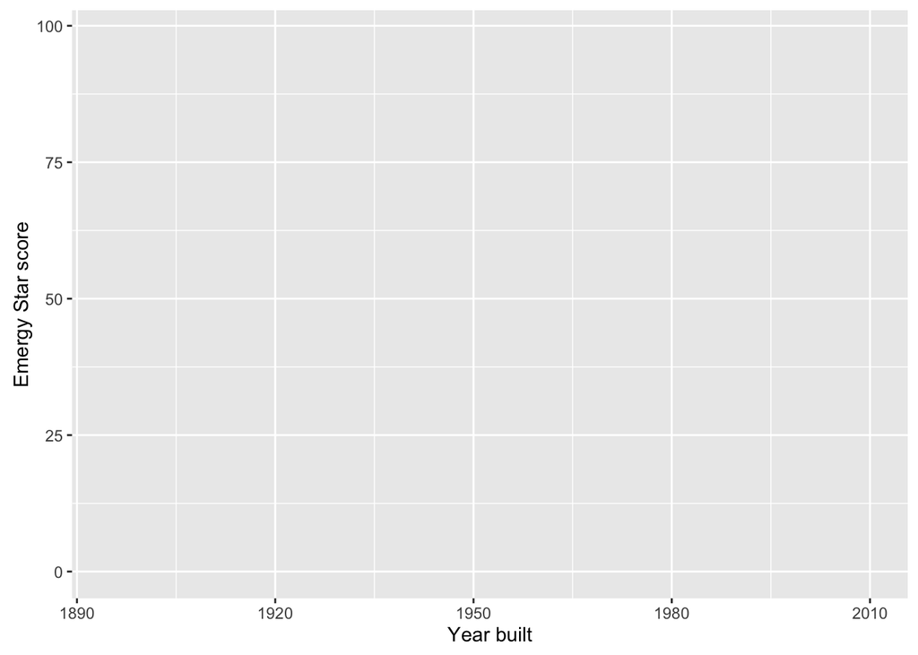

```r
ggplot(data, aes(x=Year_Built, y=ENERGY_STAR_score)) +
  xlab("Year built") +
  ylab("Emergy Star score")
```

## Glyphs: Your graphical “toppings”

And any decent graphical sandwich wouldn’t be complete without toppings! “Glyphs” are the graphical equivalent of sandwich toppings: they’re the shapes, points, lines, curves, and other visuals you put inside of the frame you’ve just created. If you take a quick look at the ggplot CRAN documentation, you’ll see that ggplot2 offers you a total of 28 different glyphs to choose from! But don’t worry–there are only a few common glyphs that you’ll need to know for now, and you can save the rest for later exploration on your own.

But first, the biggest question before working with glyphs is to decide: *What kind of data do I want my glyphs to depict?* The answer to this question will limit your choice of glyphs, since not all glyphs work with all data types.

**Some glyphs work with an “x” aesthetic only:**

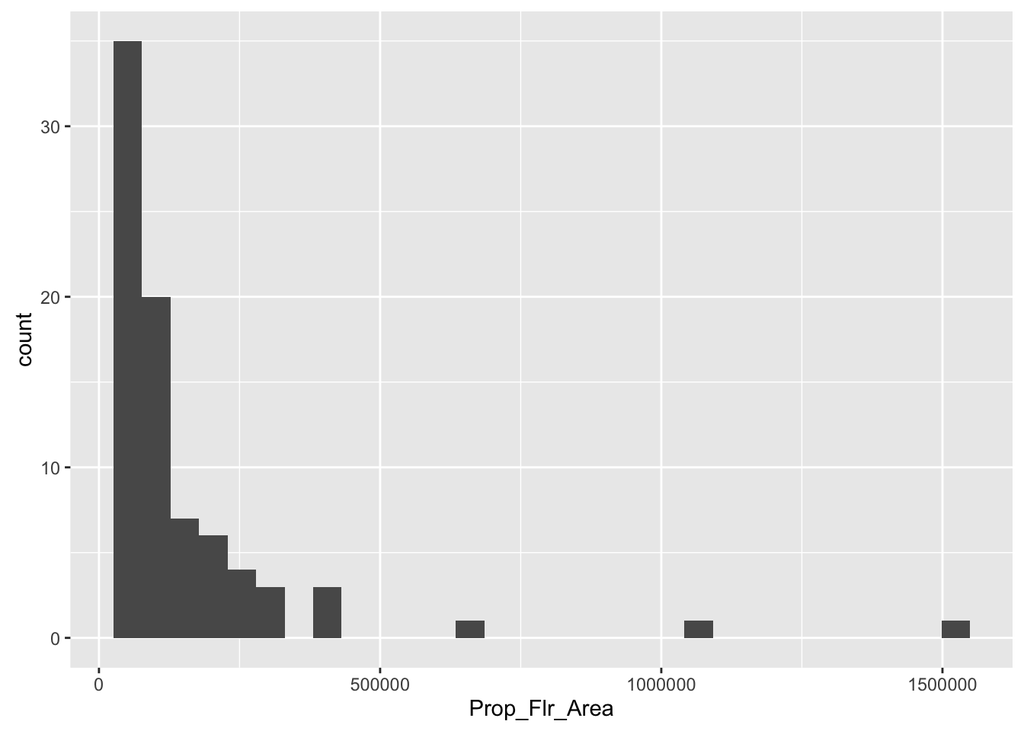

```r
ggplot(data, aes(x=Prop_Flr_Area)) +
  geom_histogram()
```

Common glyphs for “x” aesthetic only:

`geom_histogram()` - x (continuous)

`geom_density()`

**Some glyphs require both an “x” and “y” aesthetic:**

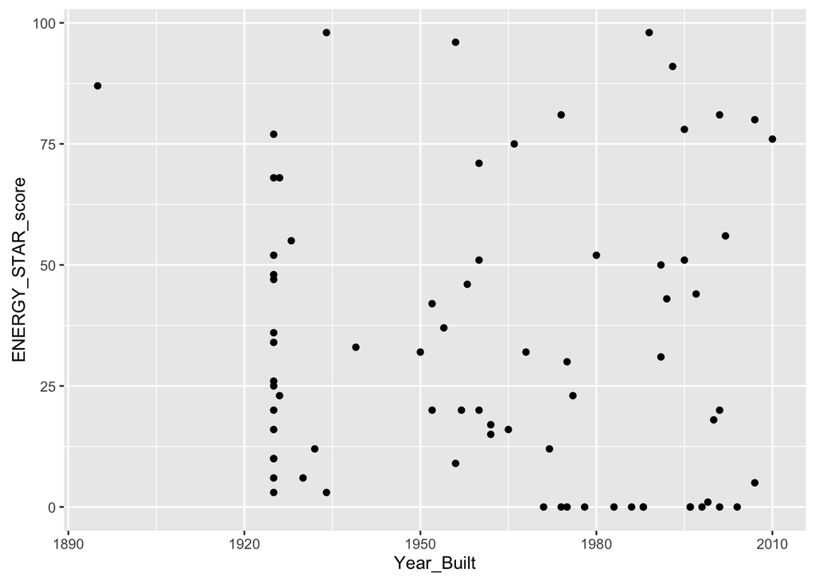

```r
ggplot(data, aes(x=Year_Built, y=ENERGY_STAR_score)) +
  geom_point()
```

Common glyphs for “x” & “y” aesthetic:

geom_point()

**Some glyphs require a categorical/grouped variable for the “x” aesthetic:**

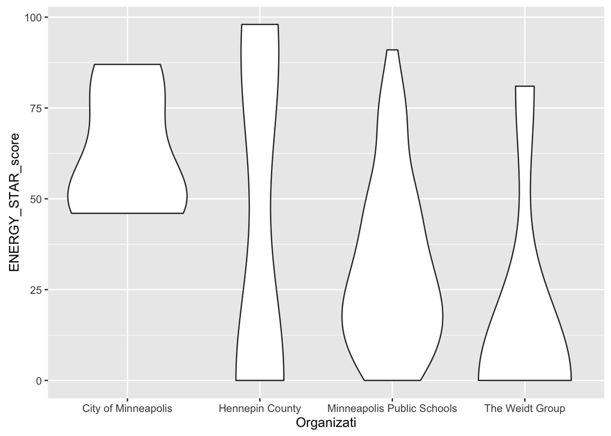

```r
ggplot(data, aes(x=Organizati, y=ENERGY_STAR_score)) +
  geom_violin()
```

`geom_violin()` - violin plot (a combination of a boxplot and a density plot)

| Glyph | Aesthetic | Graphical result |
| --- | --- | --- |
| geom_histogram() | x (continuous) | histogram |
| geom_density | x (continuous) | density plot (similar to a histogram, but with a curved line instead of a series of bars indicating where data is most densely distributed) |
| geom_point() | x (continuous) & y (continuous) | scatterplot |
| geom_boxplot() | x (categorical/grouped) & y (continuous) | grouped boxplot |
| geom_violin() | x (categorical/grouped) & y (continuous) | grouped violin plot (a comgination of a boxplot and a density plot) |

### Activity A: Practice your graphical art!

Make at least three plots featuring your choice of variables from the Minneapolis public building energy usage dataset. Make sure each of your plots uses a different glyph type. Add color to at least one of your plots.

For each plot, write a 1-2 sentence description explaining what the plot is demonstrating about the variables you looked at.

## Facets: Slice up your graphics

### Activity A:

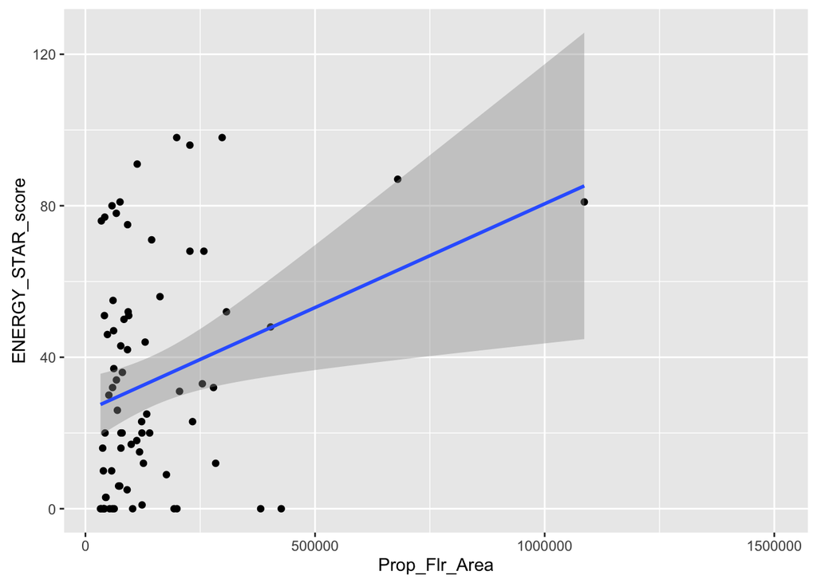

```r
ggplot(data, aes(x=Prop_Flr_Area, y=ENERGY_STAR_score)) +
  geom_point() +
  geom_smooth(method='lm')
```